# EGB103 Assignment 3

In this assignment, we continue working with GTFS realtime data from the train system in south east Queensland. There are two different types of GTFS-realtime data transmitted: In assignment 2 we looked at estimated stop arrival and departure times for each trip. The other type of GTFS-realtime data that we consider in this assignment includes the GPS (Global Positioning System) location of each train during each trip. The csv file contains the following columns:

- *timestamp*: the Unix timestamp of when the GPS location was recorded
- *line*: the name of the train line that the train is currently on
- *trip*: the identifier for the trip
- *status*: which is either StoppedAt or InTransitTo (i.e. on it's way to the next station)
- *stop*: the name of the train station that the train is either stopped at on on its way to.
- *longitude*: the east-west component of the train's current GPS location
- *latitude*: the north-south component of the train's current GPS location
- *previous*: the row index of the record corresponding to where this train just came from most recently. The first record for each trip therefore has no previous record.

# Integrating/Joining data

Often we perform joins between different data frames in order to integrate different but related data. In this assignment, we will use joins in a slightly different manner - we will instead join a data frame with itself!

## Task 1:

We wish to analyse the *distance* travelled and *speed* of each train during a trip. To do that we need both the GPS location of the train *now* and the GPS location of where it was most recently as captured in the *previous* record for that trip. To do that we are going to join each row in our data frame with the corresponding previous row. To make this joining process a little easier for you, we have provided a column named `previous` that contains the row index of the corresponding previous row. From the previous row we are only really interested in the previous timestamp, previous longitude and previous latitude. The resulting join will look something like this:

| index | timestamp | line | trip | status | stop | longitude | latitude | timestamp_previous | longitude_previous | latitude_previous |
| --- | --- | --- | --- | --- | --- | --- | --- | --- | --- | --- |
| 0 | 1677852047 | Beenleigh | 23331289-QR 22_23-32616-1792 | InTransitTo | Bethania | 153.15329 | -27.681095 | NaN | NaN | NaN |
| 1 | 1677852058 | Beenleigh | 23331289-QR 22_23-32616-1792 | InTransitTo | Bethania | 153.15329 | -27.681095 | 1.677852e+09 | 153.15329 | -27.681095 |
| 2 | 1677852067 | Beenleigh | 23331289-QR 22_23-32616-1792 | InTransitTo | Bethania | 153.15329 | -27.681095 | 1.677852e+09 | 153.15329 | -27.681095 |
| 3 | 1677852078 | Beenleigh | 23331289-QR 22_23-32616-1792 | InTransitTo | Bethania | 153.15329 | -27.681095 | 1.677852e+09 | 153.15329 | -27.681095 |
| 4 | 1677852087 | Beenleigh | 23331289-QR 22_23-32616-1792 | InTransitTo | Bethania | 153.15329 | -27.681095 | 1.677852e+09 | 153.15329 | -27.681095 |
| ... | ... | ... | ... | ... | ... | ... | ... | ... | ... | ... |
| 134163 | 1677883388 | Gympie | 23332674-QR 22_23-32617-TR12 | InTransitTo | Roma Street | 153.02150 | -27.466467 | 1.677883e+09 | 153.02222 | -27.466710 |
| 134164 | 1677883399 | Gympie | 23332674-QR 22_23-32617-TR12 | InTransitTo | Roma Street | 153.02150 | -27.466467 | 1.677883e+09 | 153.02150 | -27.466467 |
| 134165 | 1677883409 | Gympie | 23332674-QR 22_23-32617-TR12 | InTransitTo | Roma Street | 153.02150 | -27.466467 | 1.677883e+09 | 153.02150 | -27.466467 |
| 134166 | 1677883419 | Gympie | 23332674-QR 22_23-32617-TR12 | InTransitTo | Roma Street | 153.02150 | -27.466467 | 1.677883e+09 | 153.02150 | -27.466467 |
| 134167 | 1677883429 | Gympie | 23332674-QR 22_23-32617-TR12 | InTransitTo | Roma Street | 153.02150 | -27.466467 | 1.677883e+09 | 153.02150 | -27.466467 |

134168 rows × 10 columns

## Task 2: Computing distance and speed

Now that we have two different GPS coordinates in each row (the previous location and the current location), we can then compute a new column that contains the distance travelled in km. Use the Haversine distance function from week 9 practical exercises to compute the distance between coordinates.

We can similarly compute the time elapsed (in seconds) from the previous timestamp to the current timestamp, and then use that to compute a new column that contains the speed in km/h. The result should look like this:

| index | timestamp | line | trip | status | stop | longitude | latitude | previous | timestamp_previous | longitude_previous | latitude_previous | previous_previous | distance_kms | seconds_elapsed | speed_kph |
| --- | --- | --- | --- | --- | --- | --- | --- | --- | --- | --- | --- | --- | --- | --- | --- |
| 0 | 1677852047 | Beenleigh | 23331289-QR 22_23-32616-1792 | InTransitTo | Bethania | 153.15329 | -27.681095 | NaN | NaN | NaN | NaN | NaN | NaN | NaN | NaN |
| 1 | 1677852058 | Beenleigh | 23331289-QR 22_23-32616-1792 | InTransitTo | Bethania | 153.15329 | -27.681095 | 0.0 | 1.677852e+09 | 153.15329 | -27.681095 | NaN | 0.000000 | 11.0 | 0.000000 |
| 2 | 1677852067 | Beenleigh | 23331289-QR 22_23-32616-1792 | InTransitTo | Bethania | 153.15329 | -27.681095 | 1.0 | 1.677852e+09 | 153.15329 | -27.681095 | 0.0 | 0.000000 | 9.0 | 0.000000 |
| 3 | 1677852078 | Beenleigh | 23331289-QR 22_23-32616-1792 | InTransitTo | Bethania | 153.15329 | -27.681095 | 2.0 | 1.677852e+09 | 153.15329 | -27.681095 | 1.0 | 0.000000 | 11.0 | 0.000000 |
| 4 | 1677852087 | Beenleigh | 23331289-QR 22_23-32616-1792 | InTransitTo | Bethania | 153.15329 | -27.681095 | 3.0 | 1.677852e+09 | 153.15329 | -27.681095 | 2.0 | 0.000000 | 9.0 | 0.000000 |
| 5 | 1677852098 | Beenleigh | 23331289-QR 22_23-32616-1792 | InTransitTo | Bethania | 153.15738 | -27.687151 | 4.0 | 1.677852e+09 | 153.15329 | -27.681095 | 3.0 | 0.784633 | 11.0 | 256.789134 |
| 6 | 1677852108 | Beenleigh | 23331289-QR 22_23-32616-1792 | StoppedAt | Bethania | 153.15956 | -27.689257 | 5.0 | 1.677852e+09 | 153.15738 | -27.687151 | 4.0 | 0.317666 | 10.0 | 114.359919 |
| 7 | 1677852169 | Beenleigh | 23331289-QR 22_23-32616-1792 | StoppedAt | Bethania | 153.15956 | -27.689257 | 6.0 | 1.677852e+09 | 153.15956 | -27.689257 | 5.0 | 0.000000 | 61.0 | 0.000000 |
| 8 | 1677852178 | Beenleigh | 23331289-QR 22_23-32616-1792 | InTransitTo | Edens Landing | 153.16159 | -27.691206 | 7.0 | 1.677852e+09 | 153.15956 | -27.689257 | 6.0 | 0.294816 | 9.0 | 117.926551 |
| 9 | 1677852189 | Beenleigh | 23331289-QR 22_23-32616-1792 | InTransitTo | Edens Landing | 153.16340 | -27.693071 | 8.0 | 1.677852e+09 | 153.16159 | -27.691206 | 7.0 | 0.273431 | 11.0 | 89.486525 |
| 10 | 1677852199 | Beenleigh | 23331289-QR 22_23-32616-1792 | InTransitTo | Edens Landing | 153.16469 | -27.695292 | 9.0 | 1.677852e+09 | 153.16340 | -27.693071 | 8.0 | 0.277709 | 10.0 | 99.975344 |
| 11 | 1677852209 | Beenleigh | 23331289-QR 22_23-32616-1792 | InTransitTo | Edens Landing | 153.16469 | -27.695292 | 10.0 | 1.677852e+09 | 153.16469 | -27.695292 | 9.0 | 0.000000 | 10.0 | 0.000000 |
| 12 | 1677852230 | Beenleigh | 23331289-QR 22_23-32616-1792 | StoppedAt | Edens Landing | 153.17789 | -27.700308 | 11.0 | 1.677852e+09 | 153.16469 | -27.695292 | 10.0 | 1.414215 | 21.0 | 242.436940 |
| 13 | 1677852339 | Beenleigh | 23331289-QR 22_23-32616-1792 | StoppedAt | Edens Landing | 153.17789 | -27.700308 | 12.0 | 1.677852e+09 | 153.17789 | -27.700308 | 11.0 | 0.000000 | 109.0 | 0.000000 |
| 14 | 1677852350 | Beenleigh | 23331289-QR 22_23-32616-1792 | InTransitTo | Holmview | 153.18167 | -27.704386 | 13.0 | 1.677852e+09 | 153.17789 | -27.700308 | 12.0 | 0.586606 | 11.0 | 191.980008 |
| 15 | 1677852359 | Beenleigh | 23331289-QR 22_23-32616-1792 | InTransitTo | Holmview | 153.18408 | -27.707160 | 14.0 | 1.677852e+09 | 153.18167 | -27.704386 | 13.0 | 0.389146 | 9.0 | 155.658224 |
| 16 | 1677852370 | Beenleigh | 23331289-QR 22_23-32616-1792 | InTransitTo | Holmview | 153.18408 | -27.707160 | 15.0 | 1.677852e+09 | 153.18408 | -27.707160 | 14.0 | 0.000000 | 11.0 | 0.000000 |
| 17 | 1677852379 | Beenleigh | 23331289-QR 22_23-32616-1792 | InTransitTo | Holmview | 153.18408 | -27.707160 | 16.0 | 1.677852e+09 | 153.18408 | -27.707160 | 15.0 | 0.000000 | 9.0 | 0.000000 |
| 18 | 1677852391 | Beenleigh | 23331289-QR 22_23-32616-1792 | InTransitTo | Holmview | 153.18408 | -27.707160 | 17.0 | 1.677852e+09 | 153.18408 | -27.707160 | 16.0 | 0.000000 | 12.0 | 0.000000 |
| 19 | 1677852399 | Beenleigh | 23331289-QR 22_23-32616-1792 | StoppedAt | Holmview | 153.18706 | -27.709154 | 18.0 | 1.677852e+09 | 153.18408 | -27.707160 | 17.0 | 0.367726 | 8.0 | 165.476894 |

## Task 3:

We can then use this new data to compute for example the total distance travelled during trip 23331381-QR 22_23-32616-1R84:

```
16.1726532418716
```

## Task 4:

Or the average speed on each train line:

```
line
Airport        47.876790
Beenleigh      54.303309
Caboolture     63.981542
Cleveland      53.723871
Doomben        36.359824
Ferny Grove    48.913503
Gold Coast     73.705016
Gympie         68.310442
Ipswich        57.086021
Nambour        65.553947
Redcliffe      58.299851
Shorncliffe    44.247811
Springfield    59.079650
Name: speed_kph, dtype: float64
```

## Task 5:

We can also plot the speed vs time for a trip (23331381-QR 22_23-32616-1R84):

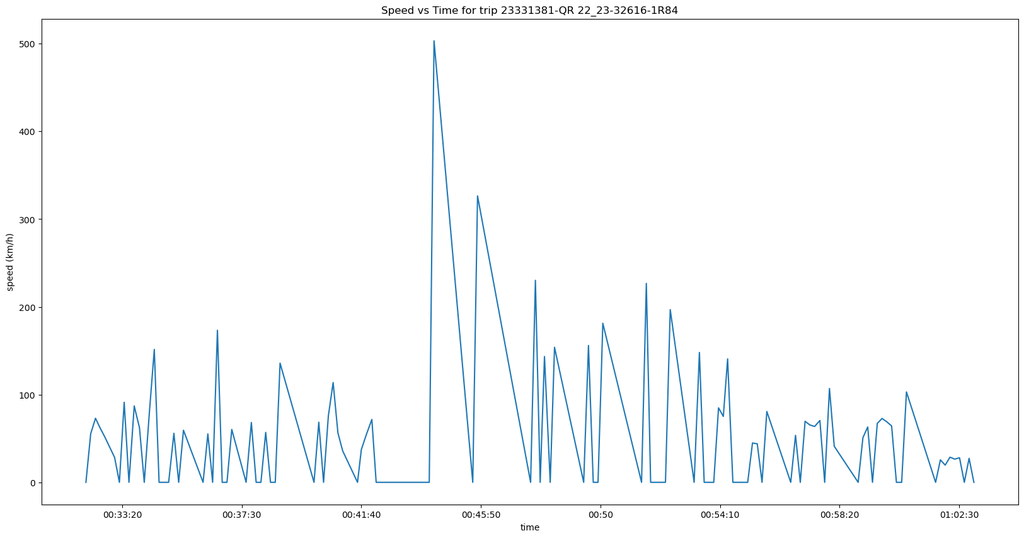

## Task 6:

Does the data in this plot look reasonable?

Let's examine the speed data for this trip more closely in tabular format:

| time | status | stop | seconds_elapsed | distance_kms | speed_kph |
| --- | --- | --- | --- | --- | --- |
| 00:23:09 | StoppedAt | Ferny Grove | NaN | NaN | NaN |
| 00:32:04 | StoppedAt | Ferny Grove | 535.0 | 0.000000 | 0.000000 |
| 00:32:14 | InTransitTo | Keperra | 10.0 | 0.153923 | 55.412176 |
| 00:32:24 | InTransitTo | Keperra | 10.0 | 0.202829 | 73.018402 |
| 00:32:33 | InTransitTo | Keperra | 9.0 | 0.156652 | 62.660829 |
| 00:32:44 | InTransitTo | Keperra | 11.0 | 0.156284 | 51.147517 |
| 00:33:04 | InTransitTo | Keperra | 20.0 | 0.157488 | 28.347808 |
| 00:33:14 | InTransitTo | Keperra | 10.0 | 0.000000 | 0.000000 |
| 00:33:24 | InTransitTo | Keperra | 10.0 | 0.253367 | 91.212174 |
| 00:33:34 | InTransitTo | Keperra | 10.0 | 0.000000 | 0.000000 |
| 00:33:45 | InTransitTo | Keperra | 11.0 | 0.265937 | 87.033844 |
| 00:33:56 | InTransitTo | Keperra | 11.0 | 0.190096 | 62.213156 |
| 00:34:06 | InTransitTo | Keperra | 10.0 | 0.000000 | 0.000000 |
| 00:34:17 | InTransitTo | Keperra | 11.0 | 0.250046 | 81.833186 |
| 00:34:27 | InTransitTo | Keperra | 10.0 | 0.420667 | 151.440136 |
| 00:34:37 | InTransitTo | Keperra | 10.0 | 0.000000 | 0.000000 |
| 00:34:47 | InTransitTo | Keperra | 10.0 | 0.000000 | 0.000000 |
| 00:34:57 | InTransitTo | Keperra | 10.0 | 0.000000 | 0.000000 |
| 00:35:08 | InTransitTo | Keperra | 11.0 | 0.170659 | 55.851993 |
| 00:35:18 | InTransitTo | Keperra | 10.0 | 0.000000 | 0.000000 |
| 00:35:28 | StoppedAt | Keperra | 10.0 | 0.164954 | 59.383423 |
| 00:36:09 | StoppedAt | Keperra | 41.0 | 0.000000 | 0.000000 |
| 00:36:19 | InTransitTo | Grovely | 10.0 | 0.153252 | 55.170652 |
| 00:36:29 | InTransitTo | Grovely | 10.0 | 0.000000 | 0.000000 |
| 00:36:39 | InTransitTo | Grovely | 10.0 | 0.481444 | 173.319914 |
| 00:36:49 | InTransitTo | Grovely | 10.0 | 0.000000 | 0.000000 |
| 00:36:59 | InTransitTo | Grovely | 10.0 | 0.000000 | 0.000000 |
| 00:37:09 | StoppedAt | Grovely | 10.0 | 0.167400 | 60.263844 |
| 00:37:39 | StoppedAt | Grovely | 30.0 | 0.000000 | 0.000000 |
| 00:37:50 | InTransitTo | Oxford Park | 11.0 | 0.208312 | 68.174959 |

[output cut: 90 more lines]

What are you observations?

# Plotting Rail Maps

Next we are going to use the GPS locations to create a 2D map of the train network.

## Task 7:

We start by plotting each of the positions that the train passes through during a trip.

For example, trip 23331381-QR 22_23-32616-1R84:

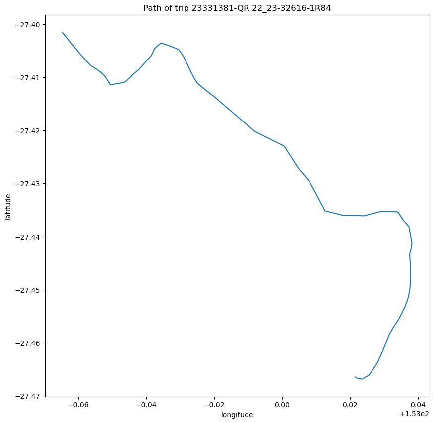

## Task 8:

We can also plot just the location of the train stations by considering only those records where the train is stopped at a station.

For example, for the same trip:

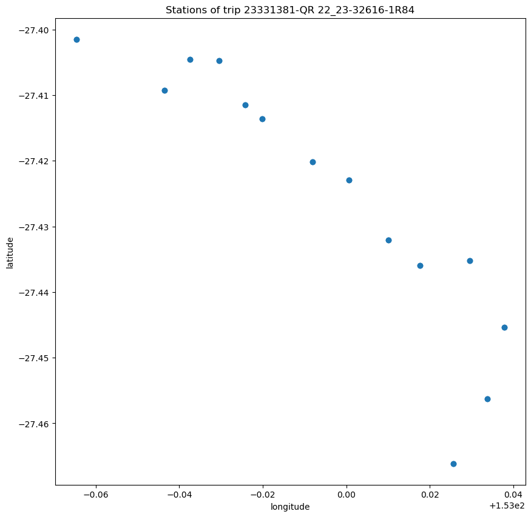

## Using matplotlib directly

The plotting functions within Pandas are implemented with the help of another Python library named matplotlib.pyplot.

Normally, we try to avoid using that module directly and instead just perform plot operations on Pandas dataframes.

However, occassionally, when we need more control, we need to use matplotlib directly. One example of this is when we want to draw multiple plots on the same surface, for example to combine the two plots above into a single plot that shows both the route taken between stations and the location of each station.

To do this we use the following Python code:

```python
import matplotlib.pyplot

# create a figure that contains a single subplot
figure, axes = matplotlib.pyplot.subplots()

# by using the same axes in each of the following plots, they are drawn on the same surface
dataframe.plot(ax=axes, other parameters)

other_dataframe.plot(ax=axes, other parameters)
```

## Task 9:

In this way we can combine the above two plots:

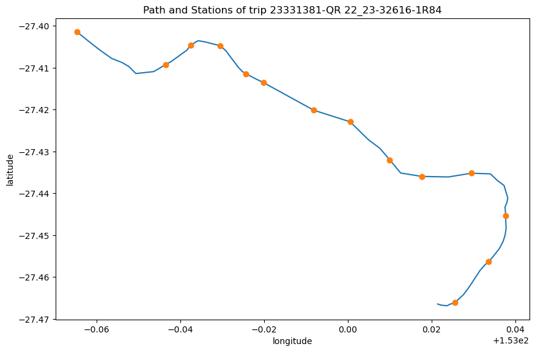

## Task 10:

Using a for loop we can also annotate each of the stations with a station name (by using the axes.annotate method)

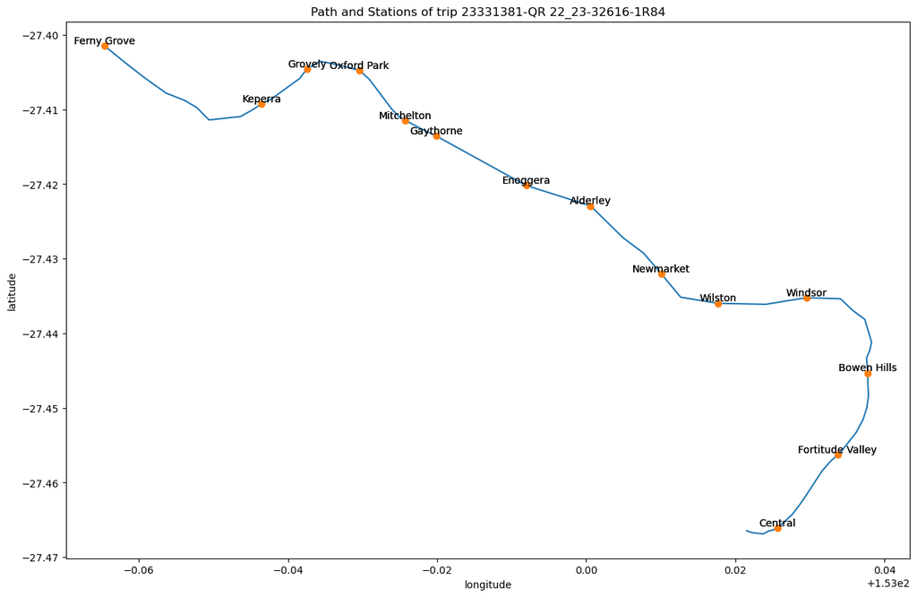

## Task 11:

Do the same for a couple of other trips. Remember not to repeat yourself!

## Task 12:

To draw a map of the entire rail network, we need to plot a trip on each train line. So, we first select one trip for each train line. It doesn't matter which trip we choose, so we will just choose the first trip:

```
line
Airport        23332373-QR 22_23-32617-DP13
Beenleigh      23331289-QR 22_23-32616-1792
Caboolture     23331539-QR 22_23-32616-D169
Cleveland      23331311-QR 22_23-32616-1M41
Doomben        23332346-QR 22_23-32617-DB01
Ferny Grove    23331381-QR 22_23-32616-1R84
Gold Coast     23331707-QR 22_23-32616-DG94
Gympie         23332646-QR 22_23-32617-T401
Ipswich        23331535-QR 22_23-32616-D574
Nambour        23332006-QR 22_23-32616-T578
Redcliffe      23331563-QR 22_23-32616-DY99
Shorncliffe    23331317-QR 22_23-32616-18A2
Springfield    23331915-QR 22_23-32616-DYA5
Name: trip, dtype: object
```

## Task 13:

We can then plot each of those trips on the same map (without stations or station names):

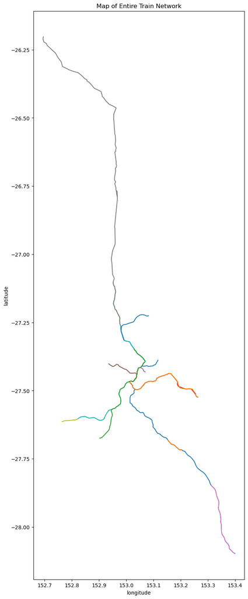

## Task 14:

As a final challenge exercise, see if you can generate an animated video of the train moving along the line during a trip.

Use the animation/visualization code from assignment 1 as a guide. Most of the *background* of the plot remains constant from one video frame to the next, so the animate function only need to modify the current location of the train.

[video not shown]

## Task 15:

Do the same for some other trips to demonstrate that you know how to not repeat yourself.